# ChIP-seq analysis workflow with gVenn using A549 datasets: identifying binding site overlaps

Supplementary data S1

Last updated

29 September 2026

**NoteInteractive notebook**

This analysis workflow is available online at:  
**https://ckntav.github.io/gVenn_manuscript/supp_data_S1.html**

[figure not shown]

# 1 Overview

This supplementary material demonstrates a complete ChIP-seq analysis workflow using the **gVenn** R package with A549 cell line data. The workflow includes:

- Loading ChIP-seq peak data
- Computing overlaps between genomic regions
- Visualizing results with Venn diagrams and UpSet plots
- Extracting specific overlap groups for downstream analysis
- Exporting results

# 2 Installation

The gVenn package is available through Bioconductor and GitHub.

You can install it from Bioconductor using:

```r
# From Bioconductor
if (!require("BiocManager", quietly = TRUE))
    install.packages("BiocManager")
BiocManager::install("gVenn")
```

The Bioconductor release version may lag behind development, so the newest features are not always available there. To install the development version from GitHub, use:

```r
# install.packages("pak")  # if not already installed
pak::pak("ckntav/gVenn")

# or, alternatively:
# install.packages("devtools")  # if not already installed
devtools::install_github("ckntav/gVenn")
```

# 3 Load required packages

```r
library(gVenn)
library(GenomicRanges)
library(knitr)
```

## 3.1 Checking gVenn version

```r
packageVersion("gVenn")
```

```
[1] '1.99.0'
```

This workflow requires gVenn version 1.99.0 or later. Earlier versions do not provide all the functions used below.

# 4 Dataset description

The dataset consists of ChIP-seq peaks from A549 cells (lung adenocarcinoma cell line) after dexamethasone treatment for two transcriptional coregulators and a transcription factor:

- **MED1**: Mediator complex subunit 1
- **BRD4**: Bromodomain-containing protein 4
- **GR**: Glucocorticoid receptor

These data represent binding sites identified from ChIP-seq experiments. To keep the dataset small and suitable for examples and tests, each set has been restricted to peaks located on *chromosome 7*.

The data originate from Tav *et al.* (2023) ([doi:10.3389/fgene.2023.1237092](https://doi.org/10.3389/fgene.2023.1237092)).

# 5 Load ChIP-seq data

The **gVenn** package includes example ChIP-seq peak data for the A549 cell line.

## 5.1 Locate data files

First, we locate the BED files included in the package:

```r
# Locate the gzipped BED files inside inst/extdata/ of the installed package
bed_med1 <- system.file("extdata", "A549_MED1_Dex.stdchr.bed.gz", package = "gVenn")
bed_brd4 <- system.file("extdata", "A549_BRD4_Dex.stdchr.bed.gz", package = "gVenn")
bed_gr   <- system.file("extdata", "A549_GR_Dex.stdchr.bed.gz", package = "gVenn")
```

## 5.2 Import peak data

Next, we import the peak sets using `rtracklayer`:

```r
# Import full consensus peak sets
med1_full <- rtracklayer::import(bed_med1)
brd4_full <- rtracklayer::import(bed_brd4)
gr_full   <- rtracklayer::import(bed_gr)
```

## 5.3 Filter to chromosome 7

To keep the dataset small and suitable for examples, we restrict the analysis to peaks on chromosome 7:

```r
# Helper function: keep only peaks on chr7
keep_chr7 <- function(gr) {
    gr[seqnames(gr) %in% c("chr7", "7")]
}

# Subset each peak set to chr7 only (keeps the dataset small and fast for examples)
med1_chr7 <- keep_chr7(med1_full)
brd4_chr7 <- keep_chr7(brd4_full)
gr_chr7 <- keep_chr7(gr_full)
```

## 5.4 Create GRangesList object

Finally, we combine the filtered peak sets into a single `GRangesList` object:

```r
# Combine into a GRangesList with descriptive names
a549_chipseq_peaks <- GRangesList("MED1_Dex_chr7" = med1_chr7,
                                  "BRD4_Dex_chr7" = brd4_chr7,
                                  "GR_Dex_chr7" = gr_chr7)

# Display the structure of the dataset
a549_chipseq_peaks
```

```
GRangesList object of length 3:
$MED1_Dex_chr7
GRanges object with 336 ranges and 2 metadata columns:
        seqnames              ranges strand |        name     score
           <Rle>           <IRanges>  <Rle> | <character> <numeric>
    [1]     chr7     1157024-1157513      * |        4997         0
    [2]     chr7     1520389-1521218      * |        4998         0
    [3]     chr7     1536927-1537642      * |        4999         0
    [4]     chr7     2309837-2310506      * |        5000         0
    [5]     chr7     3028013-3028396      * |        5001         0
    ...      ...                 ...    ... .         ...       ...
  [332]     chr7 158733134-158733544      * |        5328         0
  [333]     chr7 158818327-158819201      * |        5329         0
  [334]     chr7 158821150-158821448      * |        5330         0
  [335]     chr7 158863388-158864513      * |        5331         0
  [336]     chr7 159015348-159016094      * |        5332         0
  -------
  seqinfo: 24 sequences from an unspecified genome; no seqlengths

$BRD4_Dex_chr7
GRanges object with 604 ranges and 2 metadata columns:
        seqnames              ranges strand |        name     score
           <Rle>           <IRanges>  <Rle> | <character> <numeric>
    [1]     chr7       234690-235402      * |        9419         0
    [2]     chr7       538240-538633      * |        9420         0
    [3]     chr7     1156721-1157555      * |        9421         0
    [4]     chr7     1504294-1504733      * |        9422         0
    [5]     chr7     1506830-1507301      * |        9423         0
    ...      ...                 ...    ... .         ...       ...
  [600]     chr7 158829343-158830028      * |       10018         0
  [601]     chr7 158856251-158856723      * |       10019         0
  [602]     chr7 158863108-158864616      * |       10020         0
  [603]     chr7 159012435-159013222      * |       10021         0
  [604]     chr7 159015311-159016245      * |       10022         0
  -------
  seqinfo: 24 sequences from an unspecified genome; no seqlengths

$GR_Dex_chr7
GRanges object with 450 ranges and 2 metadata columns:
        seqnames              ranges strand |        name     score
           <Rle>           <IRanges>  <Rle> | <character> <numeric>
    [1]     chr7       729847-730122      * |        6571         0
    [2]     chr7     1156806-1157495      * |        6572         0
    [3]     chr7     1520508-1521044      * |        6573         0
    [4]     chr7     2309959-2310483      * |        6574         0
    [5]     chr7     2860620-2860960      * |        6575         0
    ...      ...                 ...    ... .         ...       ...
  [446]     chr7 158733144-158733534      * |        7016         0
  [447]     chr7 158818350-158819168      * |        7017         0
  [448]     chr7 158821076-158821582      * |        7018         0
  [449]     chr7 158863549-158864364      * |        7019         0
  [450]     chr7 159015407-159016007      * |        7020         0
  -------
  seqinfo: 24 sequences from an unspecified genome; no seqlengths
```

## 5.5 Dataset summary

```r
# Create a summary table
summary_df <- data.frame(
  "factor" = gsub("_Dex_chr7", "", names(a549_chipseq_peaks)),
  "number of peaks" = sapply(a549_chipseq_peaks, length),
  check.names = FALSE
)

kable(summary_df,
      caption = "Summary of ChIP-seq peaks for each factor")
```

Summary of ChIP-seq peaks for each factor

|  | factor | number of peaks |
| --- | --- | --- |
| MED1_Dex_chr7 | MED1 | 336 |
| BRD4_Dex_chr7 | BRD4 | 604 |
| GR_Dex_chr7 | GR | 450 |

# 6 Computing overlaps

The `computeOverlaps()` function analyzes the intersection patterns across all peak sets. For genomic ranges, it identifies regions that overlap between different ChIP-seq samples:

```r
# Compute overlaps between ChIP-seq peaks
genomic_overlaps <- computeOverlaps(a549_chipseq_peaks)

# Display the structure of the result
class(genomic_overlaps)
```

```
[1] "GenomicOverlapResult"
```

```r
names(genomic_overlaps)
```

```
[1] "regions"        "overlap_matrix" "mode"
```

By default, `computeOverlaps()` uses `mode = "reduce"`: overlapping peaks from all sets are merged into reduced regions, and each region is labeled with the sets that contributed an interval somewhere within it.

With `mode = "disjoin"`, the union of peaks is instead cut at every set boundary into disjoint regions, whose label holds at every position they cover.

In either mode, the numbers reported below are counts of regions, not of input peaks.

```r
# Same peak sets, partitioned at every set boundary
genomic_overlaps_disjoin <- computeOverlaps(a549_chipseq_peaks, mode = "disjoin")

# Number of regions under each mode
c(reduce  = length(genomic_overlaps$regions),
  disjoin = length(genomic_overlaps_disjoin$regions))
```

```
 reduce disjoin
    749    2025
```

# 7 Visualization

## 7.1 Venn diagram

The `plotVenn()` function creates area-proportional Venn diagrams to visualize the overlaps between ChIP-seq peaks:

```r
# Create a basic Venn diagram
venn <- plotVenn(genomic_overlaps)
```

[output not shown]

The message above reports `eulerr`’s goodness-of-fit diagnostics for this layout.

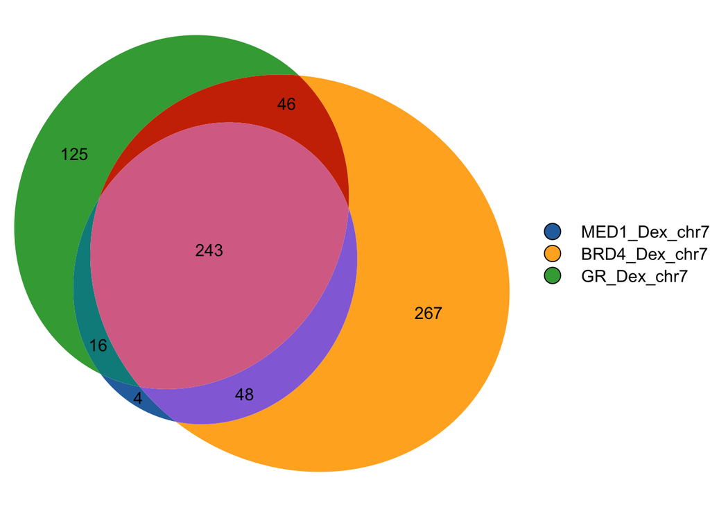

Figure 1: Basic Venn diagram showing overlaps between ChIP-seq peaks

```r
venn
```

`plotVenn()` also attaches them to the object it returns, together with the per-region errors:

```r
attr(venn, "fit_diagnostics")
```

```
$stress
[1] 2.091925e-23

$diagError
[1] 2.229461e-12

$regionError
                          MED1_Dex_chr7                           BRD4_Dex_chr7
                           2.229461e-12                            4.219958e-13
                            GR_Dex_chr7             MED1_Dex_chr7&BRD4_Dex_chr7
                           6.028511e-14                            3.018141e-13
              MED1_Dex_chr7&GR_Dex_chr7               BRD4_Dex_chr7&GR_Dex_chr7
                           7.417400e-13                            2.590289e-13
MED1_Dex_chr7&BRD4_Dex_chr7&GR_Dex_chr7
                           4.445888e-13

$undrawnRegions
character(0)
```

`diagError` is the largest difference, over all regions, between the share of the diagram’s area a region receives and the share its count requires: 0 for an exact fit, at most 1. `regionError` gives that difference region by region, and `undrawnRegions` names any non-empty region left with no area. `stress` is `eulerr`’s own loss function, also 0 for an exact fit.

Following Micallef and Rodgers (2014), who introduced `diagError`, a diagram is considered accurate when it draws every non-empty region and its `diagError` does not exceed 10⁻⁶, the threshold the message reports against. Here `diagError` is 2.229e-12 and no region is undrawn.

With four sets, ellipses cannot produce every combination of the fifteen region areas, and an exact fit rarely exists. Approximate areas matter little, since the count printed in each region carries the quantitative information. An undrawn region is more serious, since its count disappears from the figure. In that case, or when the fit is poor, use `plotUpSet()` (next section).

Set `verbose = FALSE` to silence the message; the attribute is attached either way. See the [eulerr documentation](https://jolars.github.io/eulerr/) for the definition of `stress`.